# 36-315 Homework 02, Fall 2016

Due Wednesday, September 14, 2016 (12pm ET) on Blackboard

## Homework 02 Solutions: Introduction to `ggplot` and 1-D Categorical Data

*General instructions for all assignments*:

- Use this file as the template for your submission. Delete the unecessary text (e.g. this text, the problem statements, etc). That said, keep the nicely formatted “Problem 1”, “Problem 2”, “a.”, “b.”, etc
- Upload a single `R` Markdown file (named as: [AndrewID]-HW02.Rmd – e.g. “sventura-HW02.Rmd”) to the Homework 02 submission section on Blackboard. You do not need to upload the .html file.
- The instructor and TAs will run your .Rmd file on their computer. **If your .Rmd file does not knit on our computers, you will be automatically be deducted 10 points.**
- Your file should contain the code to answer each question in its own code block. Your code should produce plots/output that will be automatically embedded in the output (.html) file
- Each answer must be supported by written statements (unless otherwise specified)
- Include the name of anyone you collaborated with at the top of the assignment
- Include the style guide you used at the top of the assignment

# Problem 1

**`R` Style Guides: Google vs. Hadley**:

One important step in facilitating reproducible research is writing easily readable, well-documented code. To ensure that you do this, you are required (for the rest of the semester) to adhere to one of the following two `R` Style Guides:

Google’s `R` Style Guide: [https://google.github.io/styleguide/Rguide.xml]

Hadley Wickham’s Advanced `R` Style Guide: [http://adv-r.had.co.nz/Style.html]

1. (9 points) What are the main differences between these two style guides? Find at least 5 differences.

Throughout was will refer to Google’s `R` Style Guide as GRSG, and Hadley Wickham’s Advanced `R` Style Guide as HWARSG:

*File Names*

- GSRG recommends using the _ character to seperate words in file names e.g. my_homework.R
- HWARSG recommends using the - character to seperate words in file names e.g. my-homework.R

*Variable Names*

- GSRG recommends using the . character to seperate words in object names, e.g. variable.name.
- HWARSG recommends using the _ character to seperate words in object names, e.g. variable_name which GRSG specifically says not to do.

*Spaces around =*

- GSRG says spaces around =âs are optional when passing parameters into a function call
- HWARSG says you must put spaces around =’s

*Spaces around function calls*

- GSRG says to place a space before left parentheses in a function call
- HWARSG says not to place a space before left parentheses in a function call

*Omitting Curly Braces* Both guides say it is acceptable to omit curly braces for short statements but GSRS says says it should go on the next line whereas HWARSG says it can be on the same line

```r
#Google
if (y < 0 && debug)
  message("Y is negative")

#Hadley Wickham
if (y < 0 && debug) message("Y is negative")

#Ok by both
if (y < 0 && debug) {
  message("Y is negative")
}
```

2. (1 point) Specify which style guide you will be using in this assignment.

Assignments not adhereing to the specified style guide will be docked up to 10 points.

# Problem 2

**Critiquing Graphs**:

*The following is an example of a critique.*

Find a graph from the internet (last 7 days – e.g. a news article, blog post, etc) or from an academic journal (last 60 days). Describe and critique your graph:

1. (5 points) **Include the graph in your assignment**. Two choices here: (1) embed the graph/image in the .html file (see below for instructions) and submit it along with your other files on Blackboard, or (2) include a link to the graph in your answer to this question.

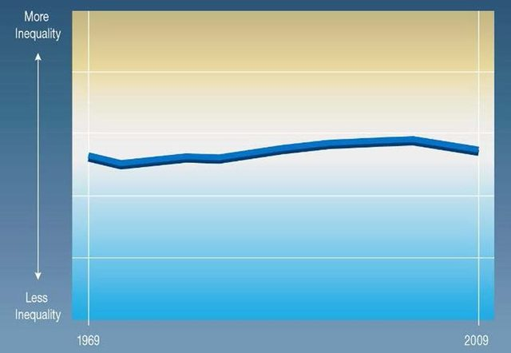

2. (5 points) **Describe the graph**. What does the graph show? What variables are plotted on the axes, via color, or via other features of the graph?

The graph is supposed to show the change in inequality in Canada from 1969 to 2009. Time, presumably in years, is plotted on the x-axis, and inequality is plotted on the y-axis. The line in the graph shows the level of inequality across the relevant time period.

3. (5 points) **Critique the graph**. Does the graph do a good job of achieving its goals? Does the graph use an unnecessary amount of data ink? Does the graph distort the actual effect/data/relationship? What are the strengths and weaknesses (if any) of the graphic? What would you change (if anything) about this graphic?

The graph does a terrible job of achieving its goals, as it is difficult for the reader to tell what exactly is going on. The colors in the graph do not provide any extra information and are a complete waste of data ink. The color scale in the background of the graph is redundant with the inequality scale on the y-axis, and can be distracting to the viewer. The 3-D line is unnecessary as well.

This graph has a number of serious weaknesses. It has no title, making it difficult for the reader to understand what the graph is supposed to show, especially if the accompanying text is not given. The label on the y-axis is almost completely useless. All we know is that a higher value on the y-axis means “more inequality” and a lower value means “less inequality.” The y-axis does not tell us the units of measurement nor the scale of “inequality.” With the lack of labeling on the y-axis, it is impossible to tell if the graph distorts the effect or the data. The x-axis shows the endpoints of the data, but does not give any labels in the middle, making it harder for the reader to find the level of inequality for a specific point in time.

If I could change this graphic, I would add better axis labels, better scales on the axes, give the graph a title, and use a simpler color scheme.

4. (5 points) **Critique the caption and/or surrounding text**. Does the text enhance the user’s understanding of the graphic? What else would you include in the caption/surrounding text to help the viewer understand the graphic?

The accompanying text with the graphic tells us that “inequality in Canada has increased just 3.4% since 1969.” This does shed some light on what exactly is being shown by the graph and the interpretation of what we’re supposed to conclude from the graph. In fact, this is really the only way the user can understand the graphic at all. However, the text could help the reader even more. It could include a description of what exactly “inequality” means, how it was measured, and how the data was collected. It could describe how the conclusion of a 3.4% increase was reached. It also could include some description of trends, rather than just comparing the endpoints.

# Problem 3

**Bar Charts**:

1. (1 point) Load the Twitter / Airline Sentiment data from Lab02. How many rows does the dataset have? How many columns does the dataset have?

```r
# Do not include any package install commands in your .Rmd file.
# Do load packages in your .Rmd file.
library(data.table)
library(curl)
library(ggplot2)
airline_tweets <- fread("https://raw.githubusercontent.com/sventura/315-code-and-datasets/master/data/Tweets.csv")
```

```r
nrow(airline_tweets)
```

```
## [1] 14640
```

```r
ncol(airline_tweets)
```

```
## [1] 15
```

The data set has 14640 rows and 15 columns.

2. (5 points) Create a bar chart of the `airline` variable. Be that your axes are properly labeled, and that the graph has a proper title. Make sure that each bar in the graph has the same color. To do this, use `+ geom_bar(fill = "red", color = "black")`. Change the `fill` and `color` commands. What do each of them do?

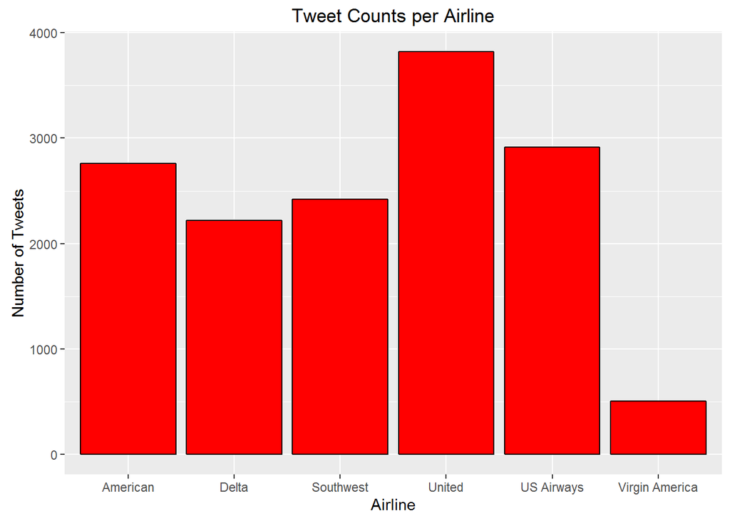

```r
ggplot(data = airline_tweets)  + geom_bar(aes(x = airline), fill = "red", color = "black") +
  labs(x = "Airline", y = "Number of Tweets") +
  ggtitle("Tweet Counts per Airline")
```

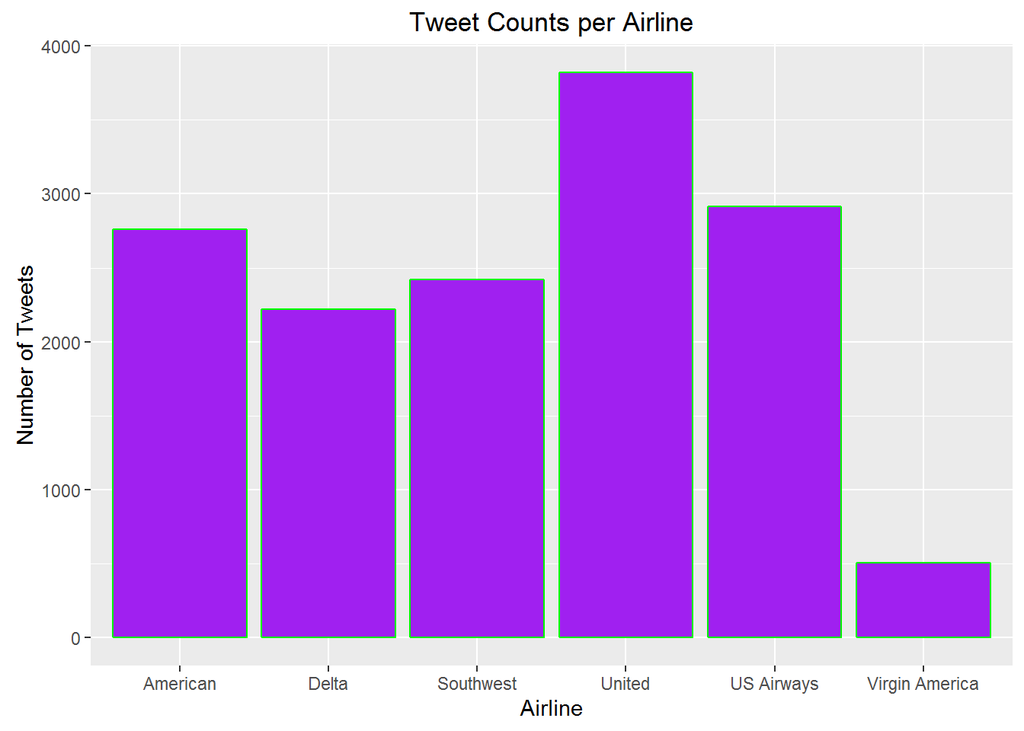

```r
ggplot(data = airline_tweets) + geom_bar(aes(x = airline), fill = "purple", color = "green") +
  labs(x = "Airline", y = "Number of Tweets") +
  ggtitle("Tweet Counts per Airline")
```

The ‘fill’ command changes the color of each bar, while the’color’ command changes the color of the outline of each bar.

3. (4 points) You can also specify HEX color values when choosing a color, e.g. `fill = "#4169E1"`. Use a website like [this one](http://www.w3schools.com/html/html_colorvalues.asp) to pick a color of your choice, and fill the bars with that color.

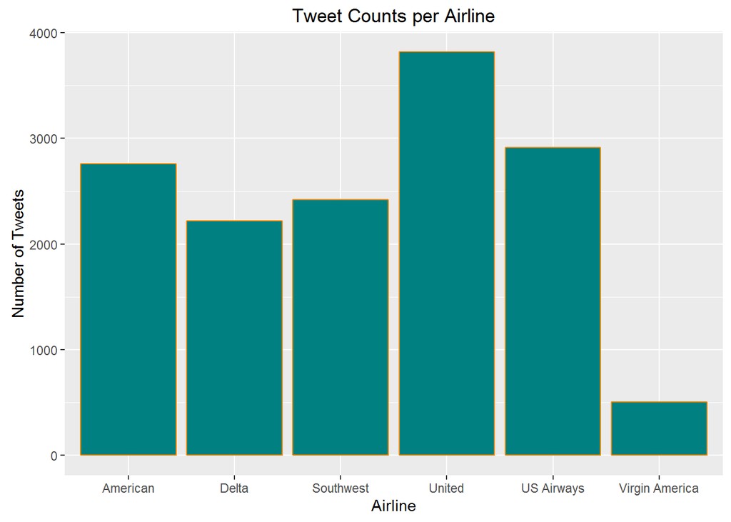

```r
ggplot(data = airline_tweets)  + geom_bar(aes(x = airline), fill = "#008080", color = "#FF8C00") +
  labs(x = "Airline", y = "Number of Tweets") +
  ggtitle("Tweet Counts per Airline")
```

# Problem 4

**Spine Charts**:

Spine Charts are similar to Bar Charts. We’ll cover them in class on Monday.

With a spine chart, we have a single (vertical) bar and multiple stacked, horizontal bars. To do this, change the aesthetic arguments in the `aes()` function in `geom_bar()`, e.g.:

`aes(x = factor(1), fill = my_variable)`

This will create a single bar on the x-axis (since `factor(1)` creates a one-category categorical variable of length one) and fill the bar in with colors corresponding to whatever categorical values are in `my_variable`.

1. (4 points) Re-create the graph from Problem 3, but use a spine chart. Be sure to correctly label the axes – remember, their interpretation may have changed from Problem 3. Include an appropriate title.

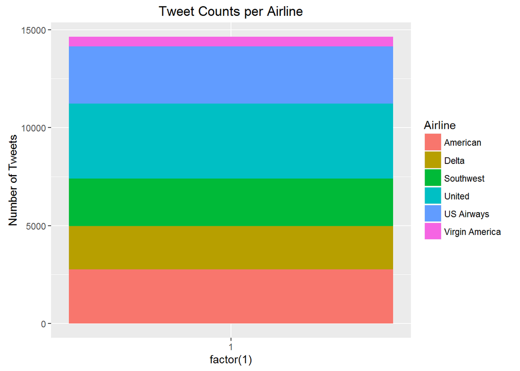

```r
ggplot(data = airline_tweets) +
  geom_bar(aes(x=factor(1), fill = airline)) +
  ggtitle("Tweet Counts per Airline") +
  labs(y = "Number of Tweets", fill = "Airline")
```

2. (3 points) In a spine chart, what are the widths of the bars proportional to (if anything)? What are the heights of the bars proportional to (if anything)? How is this different from a bar chart?

The widths of the bars are not proportional to anything, as they are all the same. The heights of the bars are proportional to the number of tweets that each airline was mentioned in. The spine chart is different from the bar chart because stacks the bars on top of each other. This makes it harder to discern the exact counts of each category, but easier to figure out the total number of tweets in the data set.

3. (3 points) `ggplot()` allows us to easily flip the orientation of our graphs without changing any of the code. To do this, you simply have to add `+ coord_flip()` to your existing code. Do this in a separate code block for the spine chart from part (a), and discuss the differences in the two plots.

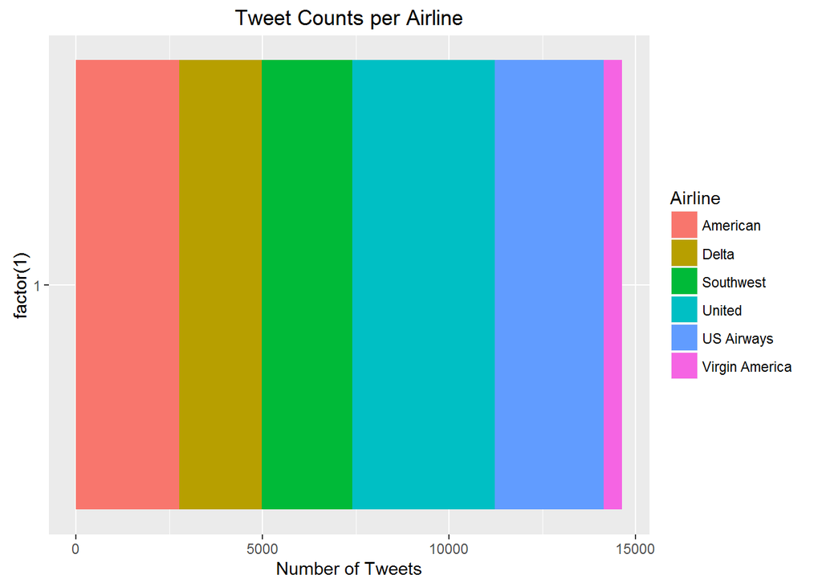

```r
ggplot(data = airline_tweets) +
  geom_bar(aes(x=factor(1), fill = airline)) +
  ggtitle("Tweet Counts per Airline") +
  labs(y = "Number of Tweets", fill = "Airline") + coord_flip()
```

In this plot, the counts are on the x-axis rather than the y-axis, and the bars are stacked horizontally. The widths of the bars are proportional to the number of tweets, while the heighst of the bars do not have any significance since they are all the same. This is the opposite of the previous graph.

4. (BONUS: 1 point) Remove the ugly `factor(1)` from the x-axis label, without changing the rest of the graphic.

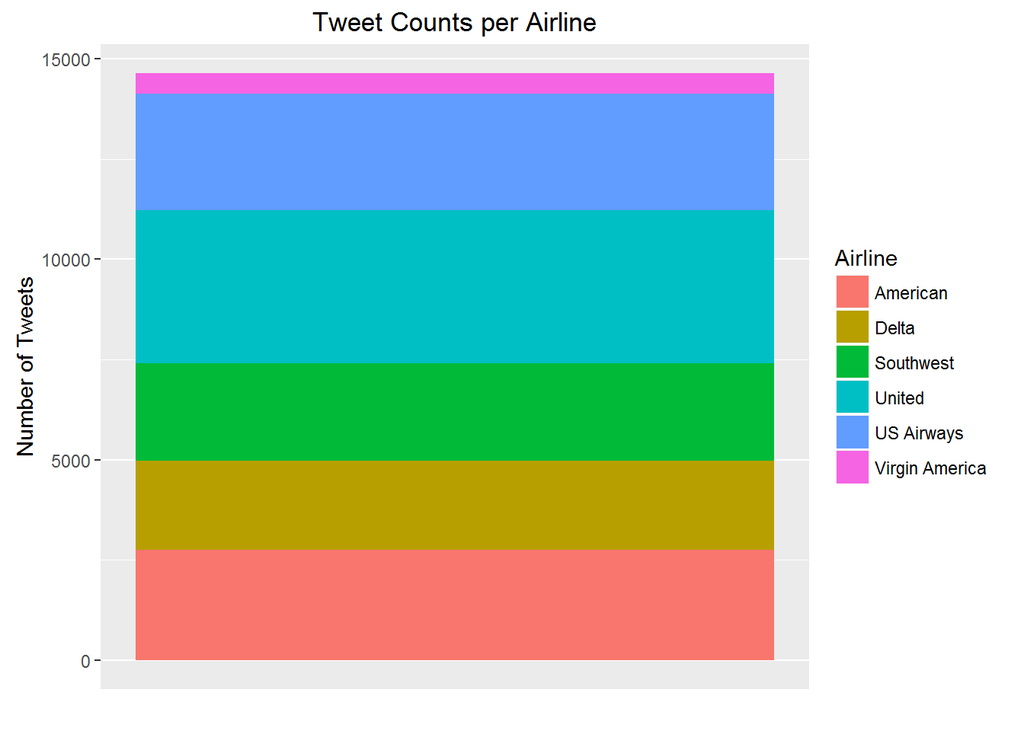

```r
ggplot(data = airline_tweets) +
  geom_bar(aes(x=factor(""), fill = airline)) +
  ggtitle("Tweet Counts per Airline") +
  labs(x = "",y = "Number of Tweets", fill = "Airline") +
  scale_x_discrete(breaks = NULL)
```

# Problem 5

**Rose Diagrams**:

1. (4 points) Re-create the graph from Problem 3, but use a rose diagram. Be sure to correctly label the axes, if necessary. Include an appropriate title.

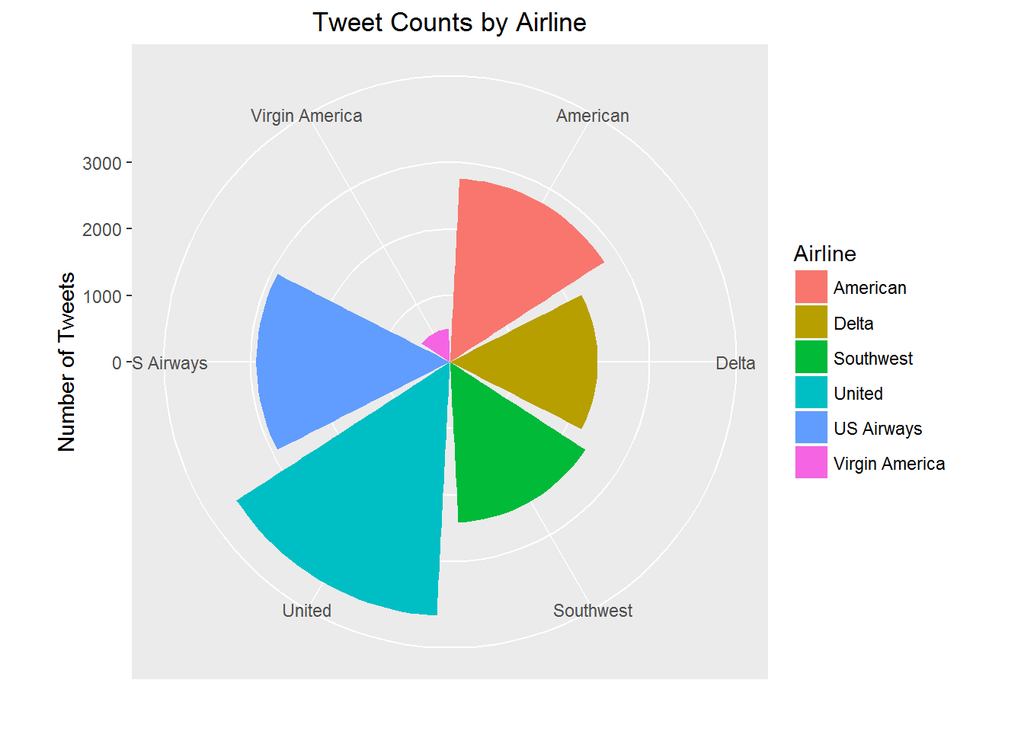

```r
ggplot(data = airline_tweets, aes(x = airline, fill = airline)) + geom_bar() + coord_polar() +
  ggtitle("Tweet Counts by Airline") + labs(x = "", y = "Number of Tweets", fill = "Airline")
```

2. (3 points) In a rose diagram, what does the radius of each rose petal correspond to (if anything)? What does the angle associated with each rose petal correspond to (if anything)?

The radius of the petal is proportional to the count - in this case the number of tweets. The angle is the same for all categories, so it does not have any meaning.

**Unfortunately, this means that the area of the petals is proportional to the count-squared, meaning that rose diagrams provide a distorted depiction of the actual counts.**

# Problem 6

**Pie Charts**:

To create a pie chart, use a similar technique to what you used to create a spine chart in Problem 4.

1. (4 points) Re-create the graph from Problem 3, but use a pie chart. Be sure to correctly label the axes, if necessary. Include an appropriate title.

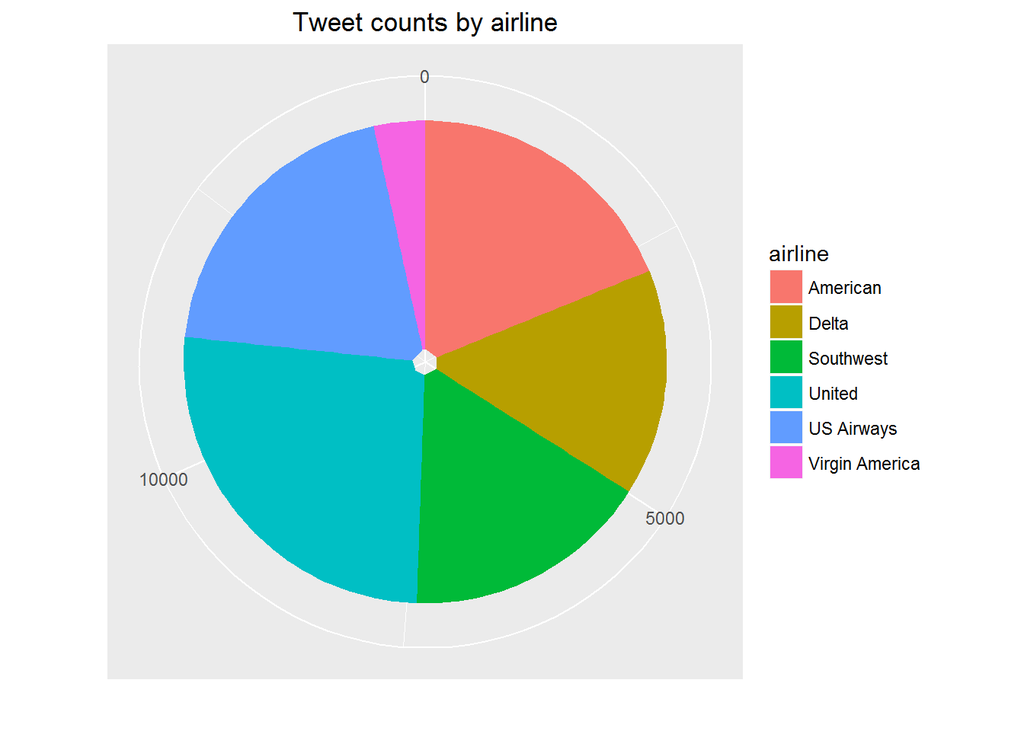

```r
ggplot(airline_tweets) + aes(x = factor(1), fill = airline) + geom_bar() +
  coord_polar(theta = "y") + ggtitle("Tweet counts by airline") +
  xlab("") + ylab("") + scale_x_discrete(breaks = NULL)
```

```r
## scale_x_discrete() removes the tick mark for the x variable
```

2. (3 points) In a pie chart, what does the radius of each pie slice correspond to (if anything)? What does the angle associated with each pie slice correspond to (if anything)?

The radius of each pie slice is equal to the radius of the circle, so it doesn’t correspond to anything in the data. The angle of each pie slice is proportional to the tweet counts.

3. (3 points) Summarize the differences between a rose diagram and a pie chart in no more than two sentences.

Rose diagrams map the visualized variable to radius, leaving the angle of each petal constant. Pie charts map the visualized variable to the angle of each slice, while leaving the radii constant.

4. (15 points) Of the four graphs we used to visualize the `airline` variable, which do you prefer? Why? Discuss the strengths (if any) and weaknesses (if any) of each.

A bar chart is usually the best option for comparing counts between categories. Its strengths are that you can easily see the counts for each variable and compare the heights of the bars for different categories. It’s somewhat difficult to eyeball a category’s proportion of the total, though.

The relative weaknesses for a spine chart are that the y-axis gives only a cumulative count, so it takes some work to get the count for an individual category, and it is more difficult to compare heights for two categories when they are stacked rather than next to each other. Spine charts can be good for displaying cumulative totals when relevant.

The main weakness of a rose diagram is that a viewer may find it more intuitive to compare by area than by radius, so they may perceive an exaggerated difference between large and small counts. However, this does mean that it may better for immediately picking out which category is biggest than spine charts or pie charts.

The main weakness of a pie chart is that comparing areas of pie slices is not as easy as comparing length in a bar chart. Pie charts also naturally represent proportions, so it may take the viewer an extra step to convert that to a count, if that’s what they’re interested in. Never make 3-D pie charts.

# Problem 7

**Statistical Tests**:

Your friend says to you, “The airlines are all equally likely to be tweeted about.”

You obviously disagree. You show your friend your graphs from the previous four problems, but your friend is still unconvinced, and wants to know if the differences across the airlines in your graph are statistically significant.

(5 points) What kind of statistical test could you use to show that the airlines are not equally likely to be tweeted about?

# Problem 8

(3 points each)

**Facetting**:

As discussed in class on Wednesday, “facetting” refers to the process of partitioning the original data according to some categorical variable, then creating the same graphic once for each subset. The resulting graphs are typically displayed in a grid, where each graph is a single “facet” of the full graphic.

This is a popular way to show how the features of the variable(s) being displayed in a particular graphic can change depending on some other variable.

With base-`R` graphics, facetting requires you to write a lot of code – code to do the subsetting, code to display the graphics, etc. Wtih `ggplot()`, facetting is very easy, as we’ll see below.

1. Recreate the plot from Problem 3, but this time, facet on the `negativereason` variable. To do this, add `+ facet_wrap(~facetting_variable)` to the existing line of code.

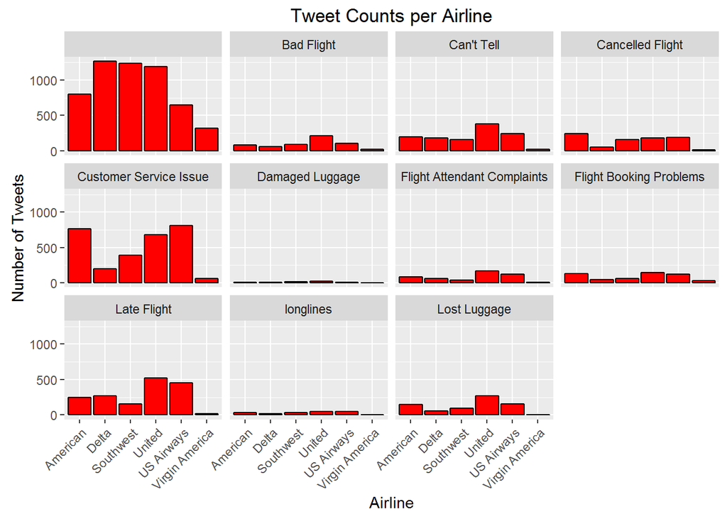

```r
ggplot(data = airline_tweets)  + geom_bar(aes(x = airline), fill = "red", color = "black") +
  labs(x = "Airline", y = "Number of Tweets") +
  ggtitle("Tweet Counts per Airline") +
  facet_wrap(~negativereason) +
  theme(axis.text.x = element_text(angle = 45, hjust = 1))
```

2. Adjust the `ncol` or `nrow` arguments in `facet_wrap()`. How do they affect the way `facet_wrap()` places each facet into a grid of graphs?

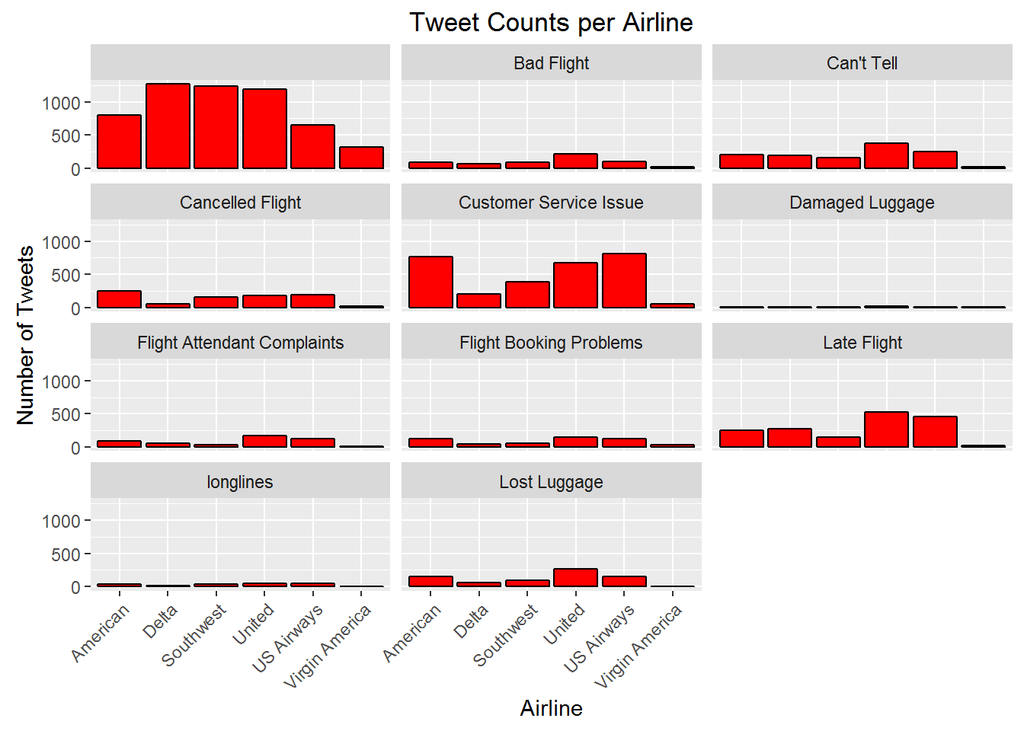

```r
ggplot(data = airline_tweets)  + geom_bar(aes(x = airline), fill = "red", color = "black") +
  labs(x = "Airline", y = "Number of Tweets") +
  ggtitle("Tweet Counts per Airline") +
  facet_wrap(~negativereason, ncol = 3) +
  theme(axis.text.x = element_text(angle = 45, hjust = 1))
```

`ncol` tells `facet_wrap()` how many columns to use while `nrow` specifies the number of rows. We can specify one or both but if we specify both it must be the case that `ncol * nrow > nvalues` where `nvalues` is the number of levels for our facting variable.

3. Sometimes, it improves our abiliity to compare across graphics if we have all the graphs in a single row or column, rather than having the plots displayed in multiple rows and columns. Recreate the plot from Problem 3, but this time, facet on the `airline_sentiment` variable using the `facet_grid()` function. To do this, add `+ facet_grid(~facetting_variable)` to the existing line of code.

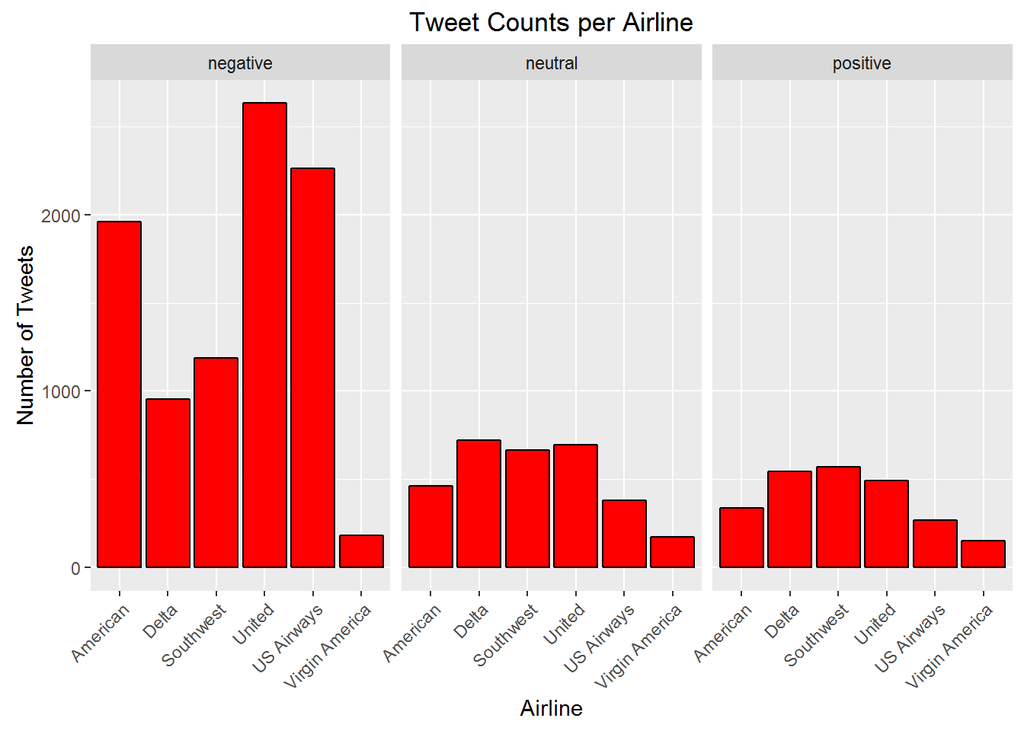

```r
ggplot(data = airline_tweets)  + geom_bar(aes(x = airline), fill = "red", color = "black") +
  labs(x = "Airline", y = "Number of Tweets") +
  ggtitle("Tweet Counts per Airline") +
  facet_grid(~airline_sentiment) +
  theme(axis.text.x = element_text(angle = 45, hjust = 1))
```

4. Recreate the graph from part (c), but this time, add `+ facet_grid(facetting_variable~.)` instead. What changed? Which version do you prefer for this particular problem?

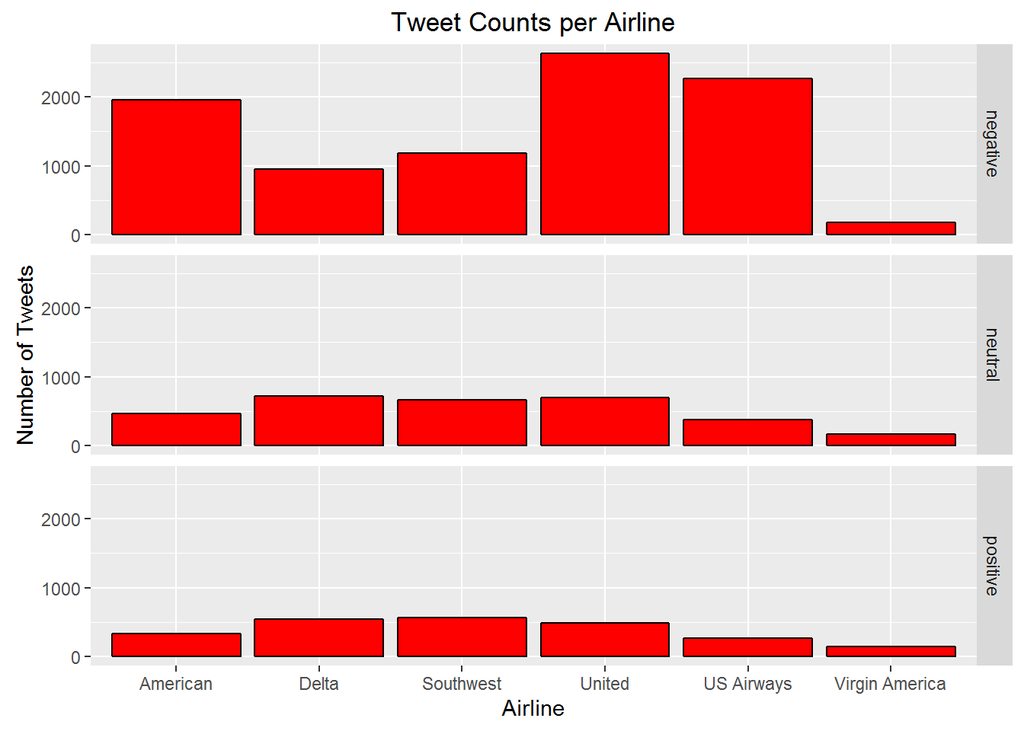

```r
ggplot(data = airline_tweets)  + geom_bar(aes(x = airline), fill = "red", color = "black") +
  labs(x = "Airline", y = "Number of Tweets") +
  ggtitle("Tweet Counts per Airline") +
  facet_grid(airline_sentiment~.)
```

Changing `facet_grid(~airline_sentiment)` to `facet_grid(airline_sentiment~.)` switches from displaying all graphs in a single row to displaying all graphs in a single column. For this data `facet_grid(airline_sentiment~.)` makes it easier to compare the relative volumes of tweets so it appears more informative.

5. We can actually facet on multiple categorical variables at once. Let’s try it. Recreate the graph from part (d), but this time, facet on both `negativereason` and `airline_sentiment`. To do this, add `+ facet_grid(negativereason~airline_sentiment)`.

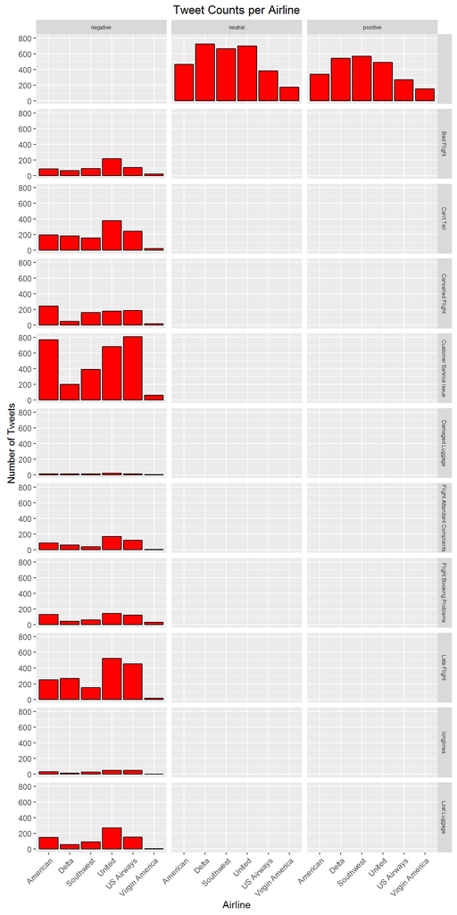

```r
ggplot(data = airline_tweets)  + geom_bar(aes(x = airline), fill = "red", color = "black") +
  labs(x = "Airline", y = "Number of Tweets") +
  ggtitle("Tweet Counts per Airline") +
  facet_grid(negativereason~airline_sentiment) +
  theme(axis.text.x = element_text(angle = 45, hjust = 1),
        strip.text = element_text(size = 6))
```

6. Why are some of the facets in your graph from part (e) empty? (Hint: Look at a contingency table of these two variables with `table(tweets$negativereason, tweets$airline_sentiment)`.)

Some of the graphs are empty because there is no data corresponding to the pair (e.g “positive” sentiment and “Bad Flight” negativereason).